[figure not shown]

# CT40XX - Week 3 - Tutorial

The following tasks are designed to test your knowledge on what we have learned during todays session, make sure to read each section carefully and then edit the code cells to fit the requirements.

Try to complete the tasks by yourself, but if you would like some help you can either:

- Look back at this weeks Lecture slides.
- Ask one of the module tutors for help during a session.
- Use Google to your advantage!

### Part 1 - Installing the libraries

In this section, we will be learning how to install, import and use the `Matplotlib` and `Numpy` libraries.

You will need to install these libraries to your Python Enivronment (The same environment you are running this Jupyter Notebook on!)

https://github.com/danielmccluskey/CT40XX-Tutorials/blob/master/Generic/Setting-Up-A-Server.md#installing-packages

### Part 2 - Importing the libraries

After installing the libraries, you may need to restart the kernel for this notebook. Do this by clicking on `Kernel->Restart` at the top of the screen.

```python
import matplotlib
import matplotlib.pyplot as plt
```

You also need to import the `numpy` library, do this in the code cell below and name it `np`!

```python
#Your code goes here!
```

### Part 3 - Creating your own Graph!

Now we are going to create our first line graph! But first we need some data to actually display!

Below I have defined a list of integers that we are going to plot on a simple line graph.

```python
iNumberList = [0,1,2,3,4,5,6,7,8,9]
```

To actually generate the graph, we're going to have to run a few functions:

- `plt.plot(ListOfData)`: Will plot your data to the graph
- `plt.ylabel("Text")`: Changes the text that displays next to the Y-Axis of your graph
- `plt.xlabel("Text")`: Changes the text that displays next to the X-Axis of your graph
- `plt.title("Text")`: Changes the title of your graph
- `plt.show()`: Shows and renders the graph to you

Using the above information, create a graph that displays the data from `iNumberList`, give it a title and different X and Y labels. Mess around with the numbers in `iNumberList` to see how it affects the graph.

```python
#Your code goes here!
```

### Part 4 - Other types of graphs

You can plot other types of graphs such as Bar charts, scatter graphs etc by using the following:

- `plt.bar(XValues, YValues)`: Displays a bar chart with the given data
- `plt.scatter(Xvalues, YValues)`: Displays a scatter graph with the given data
- `plt.pie(Values)`: Displays an evenly spread pie chart with the given values

Plot a bar chart in the code cell below using the given values. Put `sNames` along the X Axis and `iValues` on the Y axis.

*Don't forget to give your graph axis names and a title!*

```python
sNames = ["Small", "Medium", "Big"]
iValues = [5, 150, 2000]

#Your Code goes here!
```

Now do the same but with a scatter graph instead!

```python
#Your code goes here!
```

Pie charts can also be generated! If you input some names and values into `plt.pie()` it will generate you a lovely pie chart! Run the code cell below to see an example!

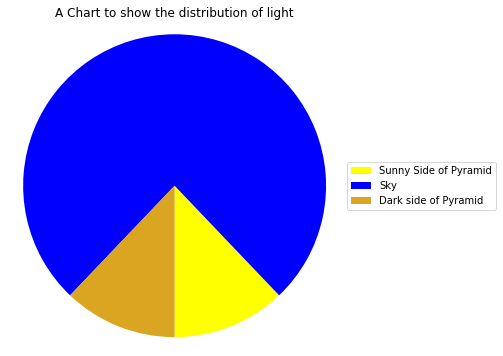

```python
sPieNames = ['Sunny Side of Pyramid','Sky','Dark side of Pyramid']
fSizes = [40, 250, 40]
sColours = ['yellow','blue','goldenrod']

plt.figure(figsize=(6,6))
plt.pie(fSizes, startangle=270, colors=sColours)
plt.legend(sPieNames, loc="center left", bbox_to_anchor=(1, 0, 0.5, 1))
plt.title("A Chart to show the distribution of light")
plt.axis('equal')
plt.show()
```

### Part 5 - Sub plotting

You can plot multiple graphs on the same diagram, this is useful for comparing information between two different graphs.

We do this by declaring a subplot:

- We first declare that we are making a new figure with multiple diagrams using `plt.figure()`
- We then declare what part of the subplot that we want to edit:
  - We do this using `plt.subplot(RowsizeColumnsizeID)`
    - Rowsize is how many rows your figure will have
    - Columnsize is how many columns your figure will have
    - ID is which graph you want to edit
  - So if we wanted to make a figure with **1 Row** and **3 Columns** we would write:
    - `plt.subplot(131)` Which will start editing the first graph in the figure
    - `plt.subplot(132)` Which would start editing the second graph in the figure
    - and so on...

Run the code cell below to see an example of this at work!

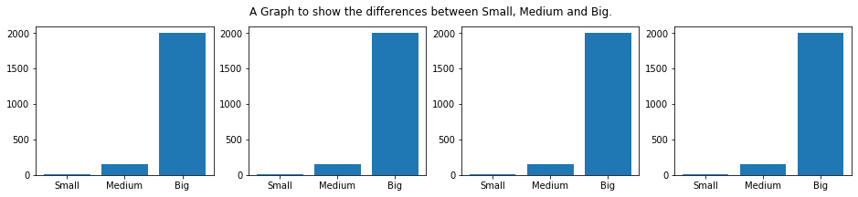

```python
plt.figure(figsize=(16,3))
plt.subplot(141)# 1 Row, 4 Columns, 1st Graph
plt.bar(sNames, iValues)

plt.subplot(142)# 1 Row, 4 Columns, 2nd Graph
plt.bar(sNames, iValues)

plt.subplot(143)# 1 Row, 4 Columns, 3rd Graph
plt.bar(sNames, iValues)

plt.subplot(144)# 1 Row, 4 Columns, 4th Graph
plt.bar(sNames, iValues)

plt.suptitle("A Graph to show the differences between Small, Medium and Big.")
plt.show()
```

Using the information above try and do the following:

- Create a Figure using **2 Rows** and **2 Columns**
- Make the First graph a **Bar Chart**
- Make the Second graph a **Scatter Graph**
- Make the Third graph a **Line chart**
- Make the Fourth graph a **Pie Chart**!

*Don't forget to add axis information and labels to your graphs!*

```python
#Your code goes here!
```

### Part 6 - Annotating your graphs

You can add annotations to your graphs to emphasise and explain different points, you can do this with the `plt.text()` function.

`plt.text(x,y,s)`

- `x`: The position on the X axis that the annotation should appear
- `y`: The position on the Y axis that the annotation should appear
- `s`: The Text that should appear at that position

When run, the example below will put a small annotation onto the graph at `0.5, 3.0` that says "Hello"

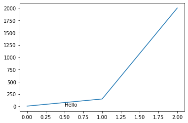

```python
plt.plot(iValues)
plt.text(x = 0.5, y = 3, s = "Hello")
plt.show()
```

There are other parameters you can use with the `plt.text()` function such as:

- `color`: The colour of the annotation text
- `backgroundcolor`: The background colour of the annotation, e.g. 'red', 'blue'
- `alpha`: How transparent the annotation is (Value between `1.0` and `0.0`)
- `fontsize`: Changes the size of the font

A full list can be found in the documentation for matplotlib [here](https://matplotlib.org/3.1.1/api/text_api.html#matplotlib.text.Text)

Using the information above, add some annotations to the given graph:

- First Annotation must have:
  - **Red** Text
  - **Blue** Background
  - **10%** transparency
  - **20** Fontsize
- Second Annotation must have:
  - Text colour of your choice!
  - **Green** Background
  - **70%** transparency
  - **40** Fontsize

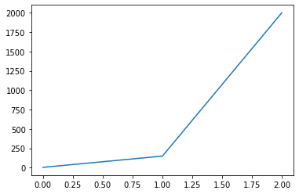

```python
plt.plot(iValues)

#Your code goes here!




plt.show()
```

### Part 7 - Annotations... Again

There are a tonne of fancy annotation features that are included with matplotlib, examples of which can be found in the documentation [here](https://matplotlib.org/3.1.1/tutorials/text/annotations.html#sphx-glr-tutorials-text-annotations-py).

Using these effectively can give your graphs the extra *pizazz* that makes it really stand out, here are a few examples:

[output not shown]

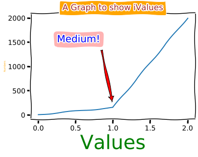

```python
with plt.xkcd():
    plt.plot(iValues)
    plt.xlabel("Values", color="green", size=40)
    plt.ylabel("Numbers", color="orange", size=5)
    plt.title("A Graph to show iValues", color="brown", backgroundcolor="orange")
    plt.grid(True)
    plt.annotate('Medium!', color="blue", xy=(1, 200), xytext=(0.25, 1500), arrowprops=dict(facecolor='red', shrink=0.05),
                 bbox=dict(boxstyle="round", fc=(1.0, 0.7, 0.7), ec="none"),
                size=20)
    plt.show()
```

### Part 7 - Styles

If you don't like the generic Blue line, black text style of the graphs, you can change the style of the graph pretty easily using any of the predefined styles. Run the cell below to see all of the available styles.

```python
print(plt.style.available)
```

[output not shown]

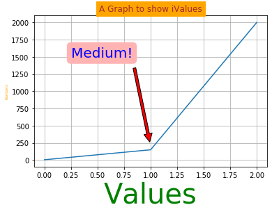

```python
plt.plot(iValues)
plt.xlabel("Values", color="green", size=40)
plt.ylabel("Numbers", color="orange", size=5)
plt.title("A Graph to show iValues", color="brown", backgroundcolor="orange")
plt.grid(True)
plt.annotate('Medium!', color="blue", xy=(1, 200), xytext=(0.25, 1500), arrowprops=dict(facecolor='red', shrink=0.05),
             bbox=dict(boxstyle="round", fc=(1.0, 0.7, 0.7), ec="none"),
            size=20)

#Your code goes here!


plt.show()
```

### Part 8 - Saving your graphs

You can save the graphs you produce as images in a quality of your choosing.

For example:

`plt.savefig('img.png', dpi=50)`

Would save at a fairly low quality, whereas

`plt.savefig('img.png', dpi=1000)`

would have superb quality, but with a much higher filesize.

Or you can save as an `svg` to get lossless quality.

`plt.savefig('img3.svg', format='svg')`

Run the cell below to generate a graph and save it in different file types.

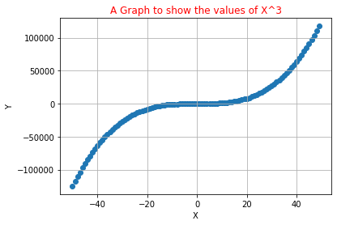

```python
iBigNumberList =[]
iXValues = []
for numb in range(100):
    iBigNumberList.append((numb-50)**3)
    iXValues.append(numb-50)

plt.scatter(x=iXValues, y=iBigNumberList)
plt.xlabel("X")
plt.ylabel("Y")
plt.title("A Graph to show the values of X^3", color="red")
plt.grid(True)
plt.savefig('img.png', dpi=1000)
plt.savefig('img2.png', dpi=20)
plt.savefig('img3.png', dpi=50)
plt.savefig('img4.svg', format='svg')
```

Here are the examples that were generated from above displayed at the same size of `600x400`.

###### 20 DPI / 3KB

[figure not shown]

###### 50 DPI / 18KB

[figure not shown]

###### 1000 DPI / 337KB

[figure not shown]

###### Lossless SVG / 33KB

[figure not shown]